# Real GDP Growth Nowcasting Models in R

MIDAS · MF-BVAR · DFM — Barbados

Author

Angelo Mazzocca

Published

June 10, 2026

This notebook walks through the R implementation of three nowcasting models for Barbados GDP growth. Each model addresses the same problem — predicting a quarterly variable using mixed-frequency indicators released at different times — but solves it differently.

The structure is the same for every model:

> **Load data → Simulate vintages → Fit → Predict → Evaluate**

# 1 Setup

## 1.1 Libraries

```r
library(Rmisc)        # CI(): confidence intervals for the BVAR prior
library(nowcastDFM)   # dfm(), predict_dfm(): Dynamic Factor Model
library(tidyverse)    # data manipulation and plotting
library(imputeTS)     # na_mean(): fill NAs with column means
library(midasr)       # midas_r(), mls(): MIDAS regression
library(mfbvar)       # set_prior(), estimate_mfbvar(): Bayesian VAR
library(lubridate)    # date arithmetic
```

## 1.2 Parameters

```r
PROJECT <- "C:/Users/agmaz/Desktop/Nwcst Training R/Barbados"
PATH_DATA   <- PROJECT
PATH_OUTPUT <- PROJECT

target_variable  <- "RGDP0000"
lags             <- seq(-2, 2)           # vintages: -2 (earliest) to +2 (latest)
train_start_date <- as.Date("2010-04-01")
test_start_date  <- as.Date("2021-09-01")
test_end_date    <- as.Date("2025-12-01")

XVars <- c("RTOU1000",   # stayover arrivals   — pub lag: 5 months
           "TREX0000",   # re-exports          — pub lag: 5 months
           "UGTR0000",   # Google Trends       — pub lag: 0 months
           "UNTL0000")   # nighttime lights    — pub lag: 0 months
```

`lags` defines the **vintage dimension**: at lag −2 we simulate having data two months before the quarter closes; at +2 we have two months of data beyond it. Running all five shows how forecast accuracy evolves as more indicators become available.

## 1.3 Data

```r
data_raw     <- read.csv(file.path(PATH_DATA, "data_processed_BB.csv"))
data_raw     <- data_raw[-c(nrow(data_raw), nrow(data_raw) - 1), ]  # drop incomplete quarters
metadata_raw <- read.csv(file.path(PATH_DATA, "meta_processed_BB.csv"))

data <- data_raw %>%
  mutate(date = as.Date(date)) %>%
  select(date, all_of(c(target_variable, XVars)))

# Keep only metadata rows for variables in scope
metadata <- metadata_raw %>%
  dplyr::filter(ticket %in% colnames(data))

# Quarterly explanatory variables get a different model spec (none here, kept for generality)
q_vars <- metadata %>%
  dplyr::filter(freq == "quarterly", ticket != target_variable) %>%
  pull(ticket)

str(data)
```

```
'data.frame':   195 obs. of  6 variables:
 $ date    : Date, format: "2010-01-01" "2010-02-01" ...
 $ RGDP0000: num  NA NA NA NA NA ...
 $ RTOU1000: num  NA 0.604 0.601 0.597 0.593 ...
 $ TREX0000: num  NA NA NA NA NA NA NA NA NA NA ...
 $ UGTR0000: num  NA -0.531 -0.533 -0.536 -0.539 ...
 $ UNTL0000: num  NA NA NA NA NA NA NA NA NA NA ...
```

`RGDP0000` is populated only at quarter-end months — every other row is `NA`. The four indicators are monthly. This mixed-frequency structure is what the three models are designed to handle, each differently.

```r
# months_lag: how long after the reference period each series is published
metadata %>% select(ticket, freq, months_lag)
```

```
    ticket      freq months_lag
1 RGDP0000 quarterly          5
2 UGTR0000   monthly          0
3 UNTL0000                    0
4 TREX0000   monthly          5
5 RTOU1000   monthly          5
```

# 2 Shared infrastructure

## 2.1 Vintage simulation

The central challenge in nowcasting evaluation is that data is not released all at once — each series arrives with its own publication lag. `gen_lagged_data()` reconstructs what the dataset looked like at any past point in time by setting the most recent observations to `NA` according to each series’ `months_lag`.

This function is **identical across all three models**.

```r
gen_lagged_data <- function(metadata, data, last_date, lag) {

  lagged_data <- data %>% dplyr::filter(date <= last_date)

  for (col in colnames(lagged_data)[-1]) {
    pub_lag   <- metadata %>% dplyr::filter(ticket == col) %>% pull(months_lag)
    condition <- nrow(lagged_data) - pub_lag + lag  # first row to set as NA
    if (condition <= nrow(lagged_data)) {
      lagged_data[condition:nrow(lagged_data), col] <- NA
    }
  }

  lagged_data %>% dplyr::filter(!is.na(date))
}
```

```r
test       <- data %>% dplyr::filter(date >= train_start_date & date <= test_end_date)
test_dates <- seq(test_start_date, test_end_date, by = "3 months")
actuals    <- test %>% dplyr::filter(date %in% test_dates) %>% pull(target_variable)

# Prediction containers: one row per test date, one column per vintage
pred_midas <- data.frame(date = test_dates)
pred_bvar  <- data.frame(date = test_dates)
pred_dfm   <- data.frame(date = test_dates)
for (lag in lags) {
  pred_midas[, as.character(lag)] <- NA
  pred_bvar[,  as.character(lag)] <- NA
  pred_dfm[,   as.character(lag)] <- NA
}
```

# 3 MIDAS

MIDAS (Mixed Data Sampling) estimates one bivariate regression per indicator — quarterly GDP on a weighted lag polynomial of the monthly series. The `mls()` function handles the frequency mismatch; the Almon polynomial (`nealmon`) keeps the number of estimated parameters small. Individual predictions are then combined using inverse in-sample RMSE weights.

**NA handling:** `na_mean()` fills every missing value before estimation and prediction. Simple and transparent, but it discards the timing information embedded in which values are missing.

## 3.1 The `midas_r()` call

```r
midas_r(y ~ mls(x, 0:3, 3, nealmon), start = list(x = c(1, -0.5)))
```

| Argument | Meaning |
| --- | --- |
| `mls(x, 0:3, 3, ...)` | Lag polynomial: lags 0–3, frequency ratio 3 (monthly → quarterly) |
| `nealmon` | Almon weights — 4 lags expressed with just 2 parameters |
| `start` | Starting values for the nonlinear optimizer |

## 3.2 Weighting

Rather than selecting the best model, MIDAS keeps all four and down-weights the least informative ones. The weight for each variable is proportional to how close its in-sample RMSE is to the best model — the worst predictor gets weight ≈ 0.

```r
weight <- sapply(XVars, function(col) {
  sqrt(mean((models[[col]]$fitted.values - y[2:length(y)])^2))  # in-sample RMSE per variable
})
adj    <- abs(weight - max(weight))   # distance from worst: worst gets 0
weight <- adj / sum(adj)              # normalize to sum to 1
```

## 3.3 Full estimation loop

```r
for (i in seq_along(test_dates)) {
  cat("Test date:", as.character(test_dates[i]), "\n")

  # Training slice: up to one quarter before the test date, all NAs filled
  train <- test %>%
    dplyr::filter(date <= test_dates[i] %m-% months(3)) %>%
    na_mean()

  # Extract quarterly GDP rows (substr pulls month digits from "YYYY-MM-DD")
  y <- train[substr(train$date, 6, 7) %in% c("03","06","09","12"), target_variable]

  # One MIDAS model per indicator
  models <- list()
  for (col in XVars) {
    if (col %in% q_vars) {
      x <- train[substr(train$date, 6, 7) %in% c("03","06","09","12"), col]
      models[[col]] <- midas_r(y ~ mls(x, 0:1, 1, nealmon), start = list(x = c(1, -0.5)))
    } else {
      x <- train[, col]
      models[[col]] <- midas_r(y ~ mls(x, 0:3, 3, nealmon), start = list(x = c(1, -0.5)))
    }
  }

  # Inverse-RMSE weights
  weight <- sapply(XVars, function(col) {
    sqrt(mean((models[[col]]$fitted.values - y[2:length(y)])^2))
  })
  adj    <- abs(weight - max(weight))
  weight <- adj / sum(adj)

  # Predict on each vintage
  for (lag in lags) {
    lagged_data <- gen_lagged_data(metadata, test, test_dates[i], lag) %>% data.frame()
    lagged_data[lagged_data$date == test_dates[i], target_variable] <- NA  # hide actual
    lagged_data <- na_mean(lagged_data)  # fill before prediction

    preds <- sapply(XVars, function(col) {
      x <- if (col %in% q_vars) {
        lagged_data[substr(lagged_data$date, 6, 7) %in% c("03","06","09","12"), col]
      } else { lagged_data[, col] }
      p <- forecast(models[[col]], newdata = list(x = x))$mean
      p[length(p)]  # last element = current quarter forecast
    })

    pred_midas[pred_midas$date == test_dates[i], as.character(lag)] <-
      weighted.mean(preds, weight)
  }
}
```

```
Test date: 2021-09-01
Test date: 2021-12-01
Test date: 2022-03-01
Test date: 2022-06-01
Test date: 2022-09-01
Test date: 2022-12-01
Test date: 2023-03-01
Test date: 2023-06-01
Test date: 2023-09-01
Test date: 2023-12-01
Test date: 2024-03-01
Test date: 2024-06-01
Test date: 2024-09-01
Test date: 2024-12-01
Test date: 2025-03-01
Test date: 2025-06-01
Test date: 2025-09-01
Test date: 2025-12-01
```

## 3.4 Performance

```r
perf_midas <- data.frame()
for (lag in lags) {
  perf_midas <- rbind(perf_midas,
    data.frame(Vintage = lag,
               RMSE    = sqrt(mean((actuals - pred_midas[[as.character(lag)]])^2)),
               Model   = "MIDAS"))
}
perf_midas
```

```
  Vintage     RMSE Model
1      -2 2.342333 MIDAS
2      -1 2.250499 MIDAS
3       0 2.146035 MIDAS
4       1 2.066571 MIDAS
5       2 2.055902 MIDAS
```

# 4 MF-BVAR

The mixed-frequency Bayesian VAR estimates one joint model over all series simultaneously. It is Bayesian in the sense that prior distributions on the coefficients regularize the estimation — important when the quarterly GDP sample is short.

The key advance over MIDAS: **the ragged edge is preserved**. Rather than filling all trailing NAs before estimation, `mfbvar` reads the staggered publication structure natively through a state-space representation. Only interior gaps (early-sample missings) need to be filled.

## 4.1 NA handling: `fill_keep_ragged_edge()`

```r
fill_keep_ragged_edge <- function(df) {
  for (col in setdiff(colnames(df), "date")) {
    x <- df[[col]]
    if (any(!is.na(x))) {
      last_obs      <- max(which(!is.na(x)))    # index of last real observation
      x[1:last_obs] <- na_mean(x[1:last_obs])   # fill interior gaps only
      df[[col]]     <- x                        # trailing NAs stay untouched
    }
  }
  df
}
```

## 4.2 Data format: `make_mf_list()`

`mfbvar` requires a named list of `ts` objects — one per series, with the correct frequency. Quarterly variables must come **last** in the list, as mfbvar partitions the system into frequency blocks internally.

```r
make_mf_list <- function(df, metadata, target_variable) {
  mf       <- list()
  q_months <- c("03", "06", "09", "12")

  for (col in setdiff(colnames(df), "date")) {
    freq_lab <- metadata %>% dplyr::filter(ticket == col) %>% pull(freq)

    if (freq_lab == "quarterly") {
      sub       <- df %>% dplyr::filter(substr(date, 6, 7) %in% q_months)
      first     <- sub$date[1]
      mf[[col]] <- ts(sub[[col]], start = c(year(first), quarter(first)), frequency = 4)
    } else {
      first     <- df$date[1]
      mf[[col]] <- ts(df[[col]], start = c(year(first), month(first)), frequency = 12)
    }
  }

  # Enforce quarterly-last ordering (mfbvar requirement)
  q_cols <- metadata %>%
    dplyr::filter(freq == "quarterly", ticket %in% names(mf)) %>%
    pull(ticket)
  mf[c(setdiff(names(mf), q_cols), q_cols)]
}
```

## 4.3 Prior and estimation: `estimate_bvar()`

```r
estimate_bvar <- function(mf_list, target_variable) {

  # Minnesota prior: 3 lags, 200 MCMC draws, GDP in its own exogenous block
  prior <- set_prior(Y = mf_list, n_lags = 3, n_reps = 200,
                     block_exo = c(target_variable))

  # Steady-state prior from 95% CI of each series
  # na.omit() prevents ragged-edge NAs from producing NA bounds
  c_interval      <- t(sapply(mf_list,
                    function(s) CI(na.omit(as.numeric(s)), ci = 0.95)))
  prior_intervals <- c_interval[, c("upper", "lower")]
  moments         <- interval_to_moments(prior_intervals)

  prior <- update_prior(prior, d = "intercept",
                        prior_psi_mean  = moments$prior_psi_mean,
                        prior_psi_Omega = moments$prior_psi_Omega)
  prior <- update_prior(prior, n_fcst = 12)  # 12-month forecast horizon

  estimate_mfbvar(prior, prior = "minn", variance = "iw")
}
```

`block_exo = "RGDP0000"` puts GDP in its own block: the indicators inform GDP, but GDP does not feed back into them.

## 4.4 Full estimation loop

The BVAR is re-estimated for every vintage — 18 × 5 = 90 MCMC runs. Each draws 200 samples from the posterior; the prediction averages them.

```r
set.seed(2025)  # MCMC is stochastic — fix seed for reproducibility

for (i in seq_along(test_dates)) {
  current_date <- test_dates[i]
  cat("Test date:", as.character(current_date), "\n")

  for (lag in lags) {

    lagged_data <- gen_lagged_data(metadata, test, current_date, lag) %>% data.frame()
    lagged_data[lagged_data$date == current_date, target_variable] <- NA

    lagged_data <- fill_keep_ragged_edge(lagged_data)  # fill interior, preserve tail
    lagged_data <- lagged_data[                        # drop rows that are all NA
      rowSums(is.na(lagged_data)) != ncol(lagged_data) - 1, ]

    mf_test <- make_mf_list(lagged_data, metadata, target_variable)
    model   <- estimate_bvar(mf_test, target_variable)

    # Average MCMC draws for the target quarter
    prediction <- predict(model, pred_bands = NULL) %>%
      dplyr::filter(variable == target_variable, fcst_date == current_date) %>%
      pull(fcst) %>% mean()

    pred_bvar[pred_bvar$date == current_date, as.character(lag)] <- prediction
  }
}
```

```
Test date: 2021-09-01
Test date: 2021-12-01
Test date: 2022-03-01
Test date: 2022-06-01
Test date: 2022-09-01
Test date: 2022-12-01
Test date: 2023-03-01
Test date: 2023-06-01
Test date: 2023-09-01
Test date: 2023-12-01
Test date: 2024-03-01
Test date: 2024-06-01
Test date: 2024-09-01
Test date: 2024-12-01
Test date: 2025-03-01
Test date: 2025-06-01
Test date: 2025-09-01
Test date: 2025-12-01
```

## 4.5 Performance

```r
perf_bvar <- data.frame()
for (lag in lags) {
  perf_bvar <- rbind(perf_bvar,
    data.frame(Vintage = lag,
               RMSE    = sqrt(mean((actuals - pred_bvar[[as.character(lag)]])^2)),
               Model   = "BVAR"))
}
perf_bvar
```

```
  Vintage     RMSE Model
1      -2 1.783257  BVAR
2      -1 1.736177  BVAR
3       0 1.519919  BVAR
4       1 1.364604  BVAR
5       2 1.290911  BVAR
```

# 5 DFM

The Dynamic Factor Model assumes all series are driven by a small number of latent factors. Parameters are estimated via the EM algorithm, which alternates between two steps: the Kalman smoother estimates the factors given the current parameters (E-step), then OLS updates the parameters given those factors (M-step).

**This completes the NA-handling arc:**

| Model | NA treatment |
| --- | --- |
| MIDAS | Fill everything before estimation |
| BVAR | Fill interior; preserve the ragged edge |
| DFM | No filling — the Kalman filter handles all missing values |

The DFM is also the only model estimated **once** rather than per test date. Factor loadings are fixed at training time; only the input vintage changes across predictions.

## 5.1 Factor structure: `blocks`

The `blocks` matrix defines which series loads on which factor — one row per series, one column per factor. Here we use a single global factor shared by all series. The production pipeline defines four factor types: `block_g` (global), `block_r` (real sector), `block_l` (labour), `block_s` (sentiment).

```r
blocks <- data.frame(block_1 = rep(1, ncol(data) - 1))
blocks
```

```
  block_1
1       1
2       1
3       1
4       1
5       1
```

## 5.2 Estimate once

```r
train_dfm <- test %>%
  dplyr::filter(date <= test_dates[1] %m-% months(3))

output_dfm <- dfm(data = train_dfm, blocks = blocks, max_iter = 300, p = 2)
```

| Argument | Meaning |
| --- | --- |
| `blocks` | Factor loading structure |
| `max_iter` | EM iteration cap |
| `p` | Lags in the factor VAR transition equation |

## 5.3 Full prediction loop

With loadings fixed, the loop contains only vintage construction and `predict_dfm()`. No estimation, no filling — the Kalman filter runs forward through whatever NAs are present.

```r
for (i in seq_along(test_dates)) {
  current_date <- test_dates[i]
  cat("Test date:", as.character(current_date), "\n")

  for (lag in lags) {
    lagged_data <- gen_lagged_data(metadata, test, current_date, lag) %>% data.frame()
    lagged_data[lagged_data$date == current_date, target_variable] <- NA

    # NAs passed in as-is — Kalman filter handles them
    prediction <- predict_dfm(lagged_data, output_dfm) %>%
      dplyr::filter(date == current_date) %>%
      pull(!!target_variable)

    pred_dfm[pred_dfm$date == current_date, as.character(lag)] <- prediction
  }
}
```

```
Test date: 2021-09-01
Test date: 2021-12-01
Test date: 2022-03-01
Test date: 2022-06-01
Test date: 2022-09-01
Test date: 2022-12-01
Test date: 2023-03-01
Test date: 2023-06-01
Test date: 2023-09-01
Test date: 2023-12-01
Test date: 2024-03-01
Test date: 2024-06-01
Test date: 2024-09-01
Test date: 2024-12-01
Test date: 2025-03-01
Test date: 2025-06-01
Test date: 2025-09-01
Test date: 2025-12-01
```

## 5.4 Performance

```r
perf_dfm <- data.frame()
for (lag in lags) {
  perf_dfm <- rbind(perf_dfm,
    data.frame(Vintage = lag,
               RMSE    = sqrt(mean((actuals - pred_dfm[[as.character(lag)]])^2)),
               Model   = "DFM"))
}
perf_dfm
```

```
  Vintage     RMSE Model
1      -2 1.634776   DFM
2      -1 1.601850   DFM
3       0 1.145765   DFM
4       1 1.163553   DFM
5       2 1.145311   DFM
```

# 6 Comparison

## 6.1 RMSE by vintage

```r
all_perf <- rbind(perf_midas, perf_bvar, perf_dfm)

all_perf %>%
  pivot_wider(names_from = Model, values_from = RMSE) %>%
  mutate(Best = case_when(
    pmin(MIDAS, BVAR, DFM) == MIDAS ~ "MIDAS",
    pmin(MIDAS, BVAR, DFM) == BVAR  ~ "BVAR",
    TRUE                             ~ "DFM")) %>%
  arrange(Vintage)
```

```
# A tibble: 5 × 5
  Vintage MIDAS  BVAR   DFM Best
    <int> <dbl> <dbl> <dbl> <chr>
1      -2  2.34  1.78  1.63 DFM
2      -1  2.25  1.74  1.60 DFM
3       0  2.15  1.52  1.15 DFM
4       1  2.07  1.36  1.16 DFM
5       2  2.06  1.29  1.15 DFM
```

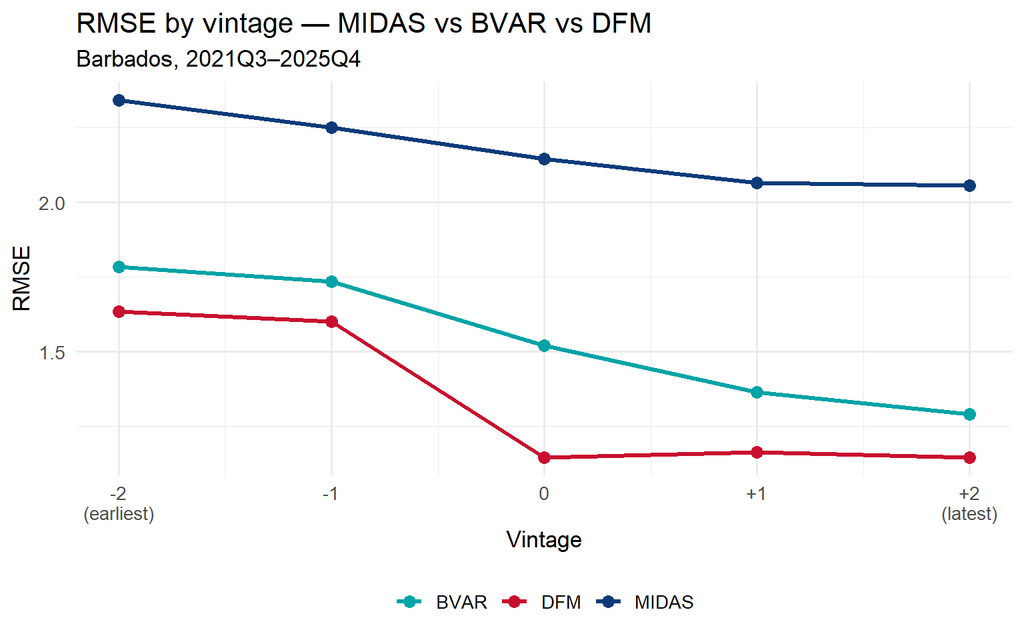

```r
ggplot(all_perf, aes(x = Vintage, y = RMSE, color = Model)) +
  geom_line(linewidth = 1.2) +
  geom_point(size = 3) +
  scale_x_continuous(breaks = -2:2,
    labels = c("-2\n(earliest)", "-1", "0", "+1", "+2\n(latest)")) +
  scale_color_manual(values = c("MIDAS" = "#0D3B7A",
                                "BVAR"  = "#00A3A6",
                                "DFM"   = "#C8102E")) +
  labs(title    = "RMSE by vintage — MIDAS vs BVAR vs DFM",
       subtitle = "Barbados, 2021Q3–2025Q4",
       x = "Vintage", y = "RMSE", color = NULL) +
  theme_minimal(base_size = 13) +
  theme(legend.position = "bottom")
```